# Lab 07-A Regression in Statistics

### Interactions and Non-linear Variables

An interaction means that the **effect** of one variable depends on the level of another variable. For example, we may think of the effect of house size on price changes depending on the house’s condition. We can add interaction terms by using `*`. Note: R will add `condition` itself as an explanatory variable in the following model:

```r
# model without interaction: the effect of sqft is the same for every condition
log_no_interaction_lm <- lm(data = sales, log(sale_price) ~ year_built + sqft + condition)

# model with interaction: sqft * condition adds sqft, condition AND sqft:condition,
# so the effect of sqft can change with the condition of the house
log_interaction_lm <- lm(data = sales, log(sale_price) ~ year_built + sqft + sqft * condition)
```

You could also have variables in you specification that are squared, cubed etc. such as:

```
# I(sqft^2) adds a squared term; cos(sqft) shows any function of X can be used
model7 <- lm(sale_price ~  sqft + I(sqft^2) + cos(sqft), data = sales)
```

The `I()` is a base R command that forces R to evaluate anything inside the `I()` before anything else. Sometimes it is needed when conducting regressions.

### Compare Models

When compare with several models, we can use `modelsummary` package to display and compare regression results in one formatted table. It helps us quickly see how coefficients, significance levels, and model fit change.

```r
# put both models in one table, one column per model
modelsummary(
  list(
    "Without Interaction Model" = log_no_interaction_lm,
    "Interaction Model" = log_interaction_lm
  ),
  stars = TRUE,  # add significance stars
  fmt = 5,       # show 5 decimal places (log coefficients are small)
  title = 'Comparison Table between Models with/without Interaction',
  output = "html")
```

Comparison Table between Models with/without Interaction

|  | Without Interaction Model | Interaction Model |
| --- | --- | --- |
| (Intercept) | 17.99260*** | 18.12357*** |
|  | (0.22241) | (0.22250) |
| year_built | -0.00251*** | -0.00243*** |
|  | (0.00011) | (0.00011) |
| sqft | 0.00037*** | 0.00023*** |
|  | (0.00000) | (0.00002) |
| condition | -0.00662 | -0.08810*** |
|  | (0.00459) | (0.01089) |
| sqft × condition |  | 0.00004*** |
|  |  | (0.00000) |
| Num.Obs. | 15409 | 15409 |
| R2 | 0.398 | 0.401 |
| R2 Adj. | 0.398 | 0.401 |
| AIC | 440451.9 | 440386.0 |
| BIC | 440490.1 | 440431.9 |
| Log.Lik. | -7678.494 | -7644.564 |
| F | 3399.128 | 2577.429 |
| RMSE | 0.40 | 0.40 |

+ p < 0.1, * p < 0.05, ** p < 0.01, *** p < 0.001

In an interaction model, the $β$ of individual variables (those also appearing in the interaction term) represent their effects only when the other interacting variable equals zero. So, it is a **baseline effect** and does not have much direct meanings. We must always interpret them together with the interaction term. In our interaction model:

We see a significant positive interaction: the positive effect of square footage on price is stronger for houses in better condition. In other words, larger houses benefit more from good condition than smaller ones.

#### Performance Metrics

**R-squared and Adjusted R-squared [larger - better]**: Mentioned in the lecture, R-squared shows how much of the variation in the response variable is explained by the model. Adjusted R-squared corrects for the number of predictors, so it is better for comparing models with different numbers of variables.

**Root Mean Squared Error (RMSE) [smaller - better]**: Root of MSE, measures the average distance between the observed and predicted values. Smaller RMSE means better model fit.

**Akaike’s Information Criterion (AIC) [smaller - better]**: AIC is good for unknown data generating process(The AIC tries to select the model that most adequately describes an unknown, high dimensional reality. Akaike’s Information Criteria is good for making asymptotically equivalent to cross-validation. You can check AIC using `AIC(model)`.

**Bayesian Information Criterion (BIC) [smaller - better]**: BIC tries to find the TRUE model among the set of candidates. A lot of times, BIC and AIC will agrees on each other, but BIC penalize models that have a lot of parameters. Danger of underfit. Bayesian Information Criteria is good for consistent estimation. You can check BIC using `BIC(model)`.

### Prediction

We can use `predict` function to generate predicted values from a regression model.

```r
# predict() returns the fitted value for each row of newdata
# note: the argument is "newdata" (an argument called "data" would be ignored)
sales$predicted <- predict(log_interaction_lm, newdata = sales)

# look at the prediction for the first sale
sales$predicted[1]
```

```
##        1
## 13.57456
```

Check the prediction, we find the value is extremely small (13.57 << real sale price). We used log transformation to response variable! We need to transform the predicted values back by taking the exponential (exp) of each prediction to return them to the original sale price scale.

```r
# undo the log: exp(log(price)) = price
sales$predicted_exp <- exp(sales$predicted)
sales$predicted_exp[1]
```

```
##        1
## 785876.9
```

## A Logistic Regression

So far our $Y$ (sale price) is a continuous number. Many questions in real estate have a **yes or no** answer instead. Was the mortgage application denied? Did the household move? Did the property sell within 30 days? For a binary $Y$ (1/0), we use **logistic regression**.

#### The HMDA Data

We use the `HMDA` dataset from the `AER` package (Applied Econometrics with R). It comes from the well known Boston Fed study by Munnell et al. (1996), *Mortgage Lending in Boston: Interpreting HMDA Data* (American Economic Review), which used Home Mortgage Disclosure Act (HMDA) records plus extra information collected from lenders. Each row is **one mortgage application** in the Boston area in 1990 ($N=2,380$). The study asked whether race was associated with mortgage denial after accounting for the applicant’s credit and financial profile.

Key variables we use (see `?HMDA` for the full list):

| Variable | Meaning |
| --- | --- |
| `deny` | **Response**: was the mortgage denied? (no/yes) |
| `pirat` | Payment to income ratio (total monthly debt / income) |
| `hirat` | Housing expense to income ratio |
| `lvrat` | Loan to value ratio (loan amount / property value) |
| `chist` | Consumer credit score, 1 (best) to 6 (worst) |
| `mhist` | Mortgage credit score, 1 (best) to 4 (worst) |
| `phist` | Public bad credit record? (no/yes) |
| `selfemp` | Is the applicant self employed? (no/yes) |
| `insurance` | Was the applicant denied mortgage insurance? (no/yes) |
| `afam` | Is the applicant African American? (no/yes) |

```r
#install.packages("AER") # you only need to run the installation once
library(AER)   # Applied Econometrics with R: includes the HMDA data
```

```r
data(HMDA)     # load the mortgage application data

# make a 0/1 version of the response for plotting and summaries
# (glm() can use the yes/no factor directly; the 0/1 copy is for our own plots and means)
hmda <- HMDA %>%
  mutate(deny01 = ifelse(deny == "yes", 1, 0))
head(hmda)     # look at the first six rows
```

```
##   deny pirat hirat     lvrat chist mhist phist unemp selfemp insurance condomin
## 1   no 0.221 0.221 0.8000000     5     2    no   3.9      no        no       no
## 2   no 0.265 0.265 0.9218750     2     2    no   3.2      no        no       no
## 3   no 0.372 0.248 0.9203980     1     2    no   3.2      no        no       no
## 4   no 0.320 0.250 0.8604651     1     2    no   4.3      no        no       no
## 5   no 0.360 0.350 0.6000000     1     1    no   3.2      no        no       no
## 6   no 0.240 0.170 0.5105263     1     1    no   3.9      no        no       no
##   afam single hschool deny01
## 1   no     no     yes      0
## 2   no    yes     yes      0
## 3   no     no     yes      0
## 4   no     no     yes      0
## 5   no     no     yes      0
## 6   no     no     yes      0
```

#### Exploring the Data

With a binary $Y$, correlation and scatterplots are less helpful. Every point sits at 0 or 1. Instead, we look at the **share of $Y=1$** across groups or across bins of $X$.

```r
# overall denial rate: the mean of a 0/1 variable is the share of 1s
mean(hmda$deny01)
```

```
## [1] 0.1197479
```

```r
# denial rate by race: count and share denied within each group
hmda %>%
  group_by(afam) %>%
  summarise(n = n(), deny_rate = mean(deny01))
```

```
## # A tibble: 2 × 3
##   afam      n deny_rate
##   <fct> <int>     <dbl>
## 1 no     2041    0.0926
## 2 yes     339    0.283
```

About 12% of all applications were denied. The raw denial rate is 28.3% for African American applicants and 9.3% for other applicants. This is a raw gap. It does not yet account for credit history, debt or loan size.

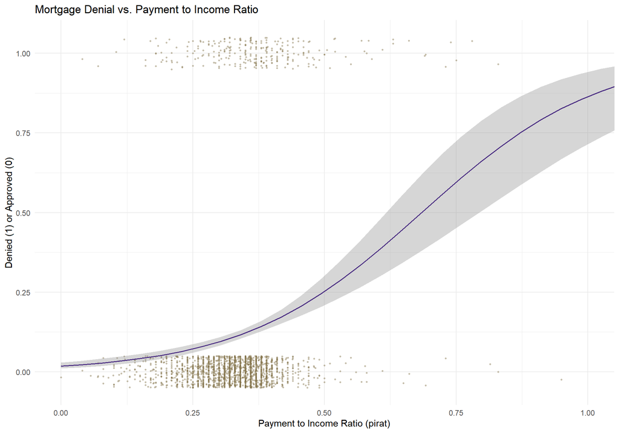

```r
ggplot(hmda, aes(x = pirat, y = deny01)) +
  # jitter moves points up/down a little so the 0s and 1s do not sit on top of each other
  geom_jitter(height = 0.05, size = 0.5, alpha = 0.4, color = "#85754d") +
  # fit a one variable logistic regression and draw its S shaped curve with a 95% band
  geom_smooth(method = "glm", method.args = list(family = binomial),
              formula = y ~ x, color = "#4b2e83", linewidth = 0.7) +
  coord_cartesian(xlim = c(0, 1)) +  # zoom in without dropping data from the fit
  labs(x = "Payment to Income Ratio (pirat)",
       y = "Denied (1) or Approved (0)",
       title = "Mortgage Denial vs. Payment to Income Ratio") +
  theme_minimal()
```

**Reading the plot**: each dot is one application, placed at 1 (denied, top band) or 0 (approved, bottom band) and jittered so they do not overlap. Most applicants have `pirat` between 0.2 and 0.45, so the bottom band is very dense there. The purple line is a one variable logistic fit. It is an **S shape** that stays between 0 and 1. The predicted denial probability is below 10% for ratios under about 0.3, then climbs quickly: about 25% at a ratio of 0.5 and about 60% at 0.75. The gray band (95% confidence interval) is narrow where data are dense and very wide above 0.5, where we only have a few applicants. (We zoom in to `pirat` $≤1$; a few extreme values go up to 3.)

#### Why Not a Linear Model?

We *can* run `lm()` on a 0/1 outcome. This is called a **linear probability model (LPM)**. But look at the fitted values:

```r
# linear probability model: plain OLS on the 0/1 outcome
lpm <- lm(deny01 ~ pirat + afam, data = hmda)

# smallest and largest predicted "probability"
range(fitted(lpm))
```

```
## [1] -0.0905136  1.5870702
```

Some predicted “probabilities” are below 0 and some are above 1. That makes no sense. The LPM also breaks the equal variance assumption by design: for a 0/1 outcome, $Var(Y∣X)=P(1−P)$, which changes with $X$. Logistic regression solves both problems.

#### The Logistic Model

Let $P=P(Y=1∣X)$. Instead of modeling $P$ directly, we model the **log odds** (also called the *logit*):

$$log(P1−P)=β0+β1X1+β2X2+…$$

- **Odds** $=P1−P$. If $P=0.2$, the odds are $0.2/0.8=0.25$ (1 denial for every 4 approvals).
- The right side is still a linear combination of $X$, just like OLS.
- We can solve back for the probability: $P=exp(β0+β1X1+…)1+exp(β0+β1X1+…)$, which always stays between 0 and 1.

The model is estimated by **maximum likelihood**, not least squares. In R, we use `glm()` (generalized linear model) with `family = binomial`.

#### Fitting the Model

We start with a simple model, then a fuller model with the credit and loan controls.

```r
# glm() = generalized linear model
# family = binomial tells R the outcome is yes/no and to use the logit link
logit_simple <- glm(deny ~ pirat + afam, data = hmda, family = binomial)
summary(logit_simple)
```

```
##
## Call:
## glm(formula = deny ~ pirat + afam, family = binomial, data = hmda)
##
## Coefficients:
##             Estimate Std. Error z value Pr(>|z|)
## (Intercept)  -4.1256     0.2684 -15.370  < 2e-16 ***
## pirat         5.3704     0.7283   7.374 1.66e-13 ***
## afamyes       1.2728     0.1462   8.706  < 2e-16 ***
## ---
## Signif. codes:  0 '***' 0.001 '**' 0.01 '*' 0.05 '.' 0.1 ' ' 1
##
## (Dispersion parameter for binomial family taken to be 1)
##
##     Null deviance: 1744.2  on 2379  degrees of freedom
## Residual deviance: 1591.4  on 2377  degrees of freedom
## AIC: 1597.4
##
## Number of Fisher Scoring iterations: 5
```

```r
# add credit history and loan controls
# chist and mhist are factors, so R creates one dummy per level (except the reference)
logit_full <- glm(deny ~ pirat + hirat + lvrat + chist + mhist + phist +
                    selfemp + insurance + afam,
                  data = hmda, family = binomial)
summary(logit_full)
```

```
##
## Call:
## glm(formula = deny ~ pirat + hirat + lvrat + chist + mhist +
##     phist + selfemp + insurance + afam, family = binomial, data = hmda)
##
## Coefficients:
##              Estimate Std. Error z value Pr(>|z|)
## (Intercept)   -6.4708     0.5108 -12.668  < 2e-16 ***
## pirat          5.1352     1.0713   4.793 1.64e-06 ***
## hirat         -0.6660     1.2672  -0.526 0.599204
## lvrat          1.7761     0.5067   3.505 0.000456 ***
## chist2         0.7085     0.2114   3.352 0.000803 ***
## chist3         0.8825     0.3101   2.846 0.004434 **
## chist4         1.5814     0.3298   4.795 1.63e-06 ***
## chist5         1.2069     0.2429   4.969 6.71e-07 ***
## chist6         1.4910     0.2305   6.470 9.81e-11 ***
## mhist2         0.4261     0.1938   2.198 0.027932 *
## mhist3         0.5491     0.4679   1.173 0.240602
## mhist4         0.5780     0.6278   0.921 0.357222
## phistyes       1.2677     0.2066   6.135 8.51e-10 ***
## selfempyes     0.6699     0.2128   3.148 0.001645 **
## insuranceyes   4.5646     0.5558   8.212  < 2e-16 ***
## afamyes        0.6842     0.1767   3.873 0.000108 ***
## ---
## Signif. codes:  0 '***' 0.001 '**' 0.01 '*' 0.05 '.' 0.1 ' ' 1
##
## (Dispersion parameter for binomial family taken to be 1)
##
##     Null deviance: 1744.2  on 2379  degrees of freedom
## Residual deviance: 1273.3  on 2364  degrees of freedom
## AIC: 1305.3
##
## Number of Fisher Scoring iterations: 6
```

How to read the `glm()` table? Most parts look like the `lm()` table, with a few differences:

- **Estimate**: the change in the **log odds** of $Y=1$ for a one unit increase in $X$, holding other variables constant. The sign tells the direction. The size is hard to read directly.
- **z value**: estimate divided by standard error. It plays the same role as the t value in `lm()`. The test is $H0:β=0$.
- **Pr(>|z|)**: the p value for that test.
- **Null deviance vs. Residual deviance**: deviance measures how badly the model fits ($−2×$ log likelihood). The null deviance is for a model with only the intercept. A large drop means the $X$s help.
- There is **no R-squared** and no residual standard error. We use AIC, BIC and pseudo R-squared instead (see below).

#### From Log Odds to Odds Ratios

Log odds are not intuitive, so we usually report **odds ratios**. Like the log transformation in the linear model, we take `exp()` of $β$:

$$log(oddschanged)−log(oddsoriginal)=β1exp(β1)=oddschangedoddsoriginal$$

```r
# coef() gives log odds; exp() turns them into odds ratios
# confint() on a glm gives profile likelihood intervals; exp() puts them on the OR scale
# cbind() glues the columns together into one table
exp(cbind(OR = coef(logit_simple), confint(logit_simple)))
```

```
##                       OR        2.5 %       97.5 %
## (Intercept)   0.01615448  0.009392082   0.02687566
## pirat       214.94067334 53.848128122 931.65749990
## afamyes       3.57077239  2.674741842   4.74680906
```

How to read an odds ratio (OR):

- OR $=1$: no association.
- OR $>1$: higher odds of $Y=1$. OR $=1.5$ means 50% higher odds.
- OR $<1$: lower odds of $Y=1$. OR $=0.8$ means 20% lower odds.
- If the 95% confidence interval of the OR contains 1, the variable is not significant at the 5% level.

**In our case**: in `logit_simple`, the OR for `afamyes` is about 3.57 (95% CI: 2.67 to 4.75). Holding the payment to income ratio constant, African American applicants have about 3.6 times the odds of denial. The OR for `pirat` is huge (about 215) because a one unit change in `pirat` (from 0 to 1, i.e. 0% to 100% of income) is a very large change. A 0.1 increase is more meaningful: $exp(5.37×0.1)≈1.71$, so 71% higher odds of denial. This is the same idea as the 100 sqft example in the linear model.

> **Odds are not probabilities.** “3.6 times the odds” does **not** mean “3.6 times as likely”. When the outcome is rare (say below 10%), the two are close. When it is common, they can be very different. We will convert results to probabilities in the Prediction section.

### Check Assumptions of Logistic Regression

Logistic regression has **fewer** assumptions than OLS, but they are different. Compare with the six OLS assumptions above:

| OLS assumption | Logistic regression |
| --- | --- |
| 1. Linearity in $Y$ | **Linearity in the log odds** for each continuous $X$ |
| 2. Independent errors | **Still required**: independent observations |
| 3. No perfect collinearity | **Still required**: check VIF |
| 4. Zero conditional mean | **Still required**: no omitted confounders (design, not a plot) |
| 5. Equal variance | **Not required**: variance is $P(1−P)$ by design |
| 6. Normal errors | **Not required**: $Y$ follows a binomial (Bernoulli) distribution |
| (new) | **Binary outcome**, **no extreme influential points**, **large enough sample** and **no (quasi) separation** |

Because assumptions 5 and 6 are not required, the Q–Q plot from `plot(model)` is **not meaningful** for logistic regression. The residuals of a 0/1 outcome are never normal. Do not use it.

#### Binary Outcome

The response must have exactly two categories. `deny` is a factor with levels `no` and `yes`. R models the probability of the **second level** (`yes`), so check the level order.

```r
levels(hmda$deny) # R models P(second level), here P(deny = "yes")
```

```
## [1] "no"  "yes"
```

```r
table(hmda$deny)  # how many of each outcome
```

```
##
##   no  yes
## 2095  285
```

#### Linearity in the Log Odds

Logistic regression does not need $Y$ to be linear in $X$. It needs the **log odds** to be linear in each continuous $X$. A simple check is the **empirical logit plot**: cut $X$ into bins (here 10 equal sized groups), compute the share of denials in each bin, and convert it to log odds. If the points follow a straight line, the assumption is fine.

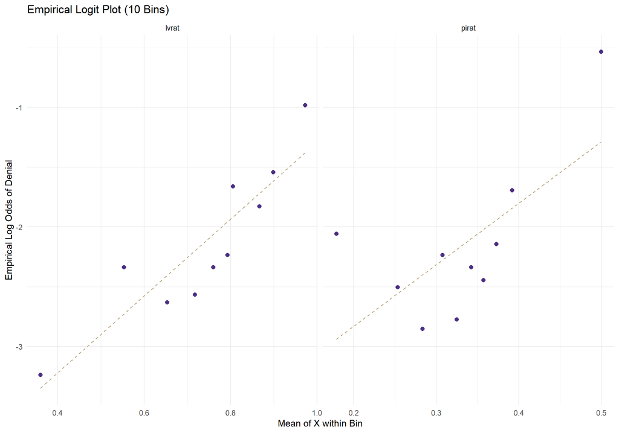

```r
emp_logit <- hmda %>%
  # stack pirat and lvrat into one column so we can treat them the same way
  pivot_longer(cols = c(pirat, lvrat), names_to = "variable", values_to = "xvalue") %>%
  group_by(variable) %>%
  mutate(bin = ntile(xvalue, 10)) %>%   # cut each X into 10 groups of equal size
  group_by(variable, bin) %>%
  summarise(x_mean = mean(xvalue),       # middle of the bin
            p = mean(deny01),            # share denied in the bin
            log_odds = log(p / (1 - p)), # convert the share to log odds
            .groups = "drop")

ggplot(emp_logit, aes(x = x_mean, y = log_odds)) +
  geom_point(color = "#4b2e83", size = 2) +              # one point per bin
  geom_smooth(method = "lm", formula = y ~ x, se = FALSE, # straight reference line
              color = "#b7a57a", linewidth = 0.5, linetype = "dashed") +
  facet_wrap(~ variable, scales = "free_x") +
  labs(x = "Mean of X within Bin", y = "Empirical Log Odds of Denial",
       title = "Empirical Logit Plot (10 Bins)") +
  theme_minimal()
```

**In our case**:

- `lvrat` (left panel): the points rise from about -3.2 to -1.0 and follow the dashed line fairly well. The two bins in the middle are a bit noisy, and the highest bin sits above the line, but there is no clear curve. Roughly linear.
- `pirat` (right panel): the pattern is **not** a straight line. The lowest bin (mean ratio about 0.18) has *higher* log odds than the next few bins, then the points are flat around -2.5, and the highest bin (mean about 0.5) jumps to about -0.5. This is a **J shape**. The effect of debt is not constant: it matters little in the normal range and a lot once the ratio gets high. (The slightly higher denial rate at very low ratios may reflect applicants with unusual or incomplete income records.)

A formal check is the **Box–Tidwell test**. We add $X×log(X)$ for each continuous $X$. If that extra term is significant, the log odds are not linear in $X$. (It needs $X>0$, so we drop a few zero values.)

```r
# log(X) needs X > 0, so drop the few rows with a zero ratio
bt_data <- hmda %>% filter(pirat > 0, hirat > 0, lvrat > 0)

# Box-Tidwell: add X * log(X) for each continuous X we want to test
box_tidwell <- glm(deny ~ pirat + I(pirat * log(pirat)) + hirat +
                     lvrat + I(lvrat * log(lvrat)) + chist + mhist +
                     phist + selfemp + insurance + afam,
                   data = bt_data, family = binomial)
```

```
## Warning: glm.fit: fitted probabilities numerically 0 or 1 occurred
```

```r
# show only the two test terms: a small p value means the logit is NOT linear in that X
coef(summary(box_tidwell))[c("I(pirat * log(pirat))", "I(lvrat * log(lvrat))"), ]
```

```
##                        Estimate Std. Error   z value   Pr(>|z|)
## I(pirat * log(pirat)) 6.6649542   2.846868 2.3411533 0.01922427
## I(lvrat * log(lvrat)) 0.7093261   1.808486 0.3922209 0.69489501
```

The `pirat` term is significant (p ≈ 0.02) but the `lvrat` term is not (p ≈ 0.69). This confirms the plot: `pirat` needs some adjustment. You may also see the warning `fitted probabilities numerically 0 or 1 occurred`. That is a hint of a few extreme points, which we check next.

#### Influential Points

Just like the linear model, a few unusual applications can pull the estimates. `plot(model, which = 4)` shows Cook’s distance and `which = 5` shows residuals vs leverage. Both work for `glm()`.

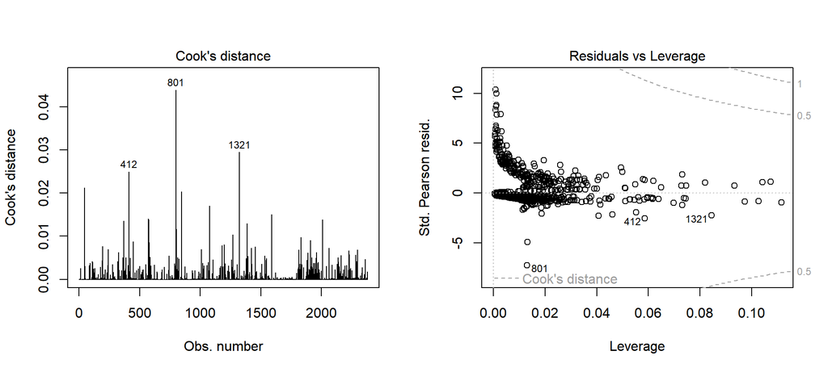

```r
par(mfrow = c(1, 2))         # two plots side by side
plot(logit_full, which = 4)  # Cook's distance for every application
plot(logit_full, which = 5)  # standardized Pearson residuals vs leverage
```

```r
par(mfrow = c(1, 1))         # reset the layout
```

```r
# look at the three rows labeled in the plots
hmda[c(801, 1321, 412), c("deny", "pirat", "hirat", "lvrat", "insurance")]
```

```
##      deny pirat hirat     lvrat insurance
## 801    no  0.22  0.19 1.9500000       yes
## 1321   no  1.28  0.73 0.7075472        no
## 412    no  0.95  0.44 0.5470588        no
```

```r
# how many applications have debt payments larger than income?
sum(hmda$pirat > 1)
```

```
## [1] 5
```

**Reading the plots**:

- **Cook’s distance** (left): one spike per application. The largest values are rows 801 (about 0.044), 1321 (0.029) and 412 (0.025). All are far below 0.5. Most applications are close to 0.
- **Residuals vs Leverage** (right): the points form **two curved bands**. This always happens with a 0/1 outcome. The upper band is the denied applicants (positive residuals), the lower band is the approved ones (negative residuals). Do not read the bands as a problem. Row **801** has the most extreme residual (about -7): the model gave it a very high chance of denial, but it was approved. Rows **1321** and **412** have the highest leverage of the labeled points because their debt ratios are extreme. The Cook’s 0.5 contours sit far away in the corners, so no point is highly influential.

**What are these rows?** Row 1321 has a payment to income ratio of 1.28, meaning monthly debt payments are larger than income. Five applications have `pirat` $>1$, and one has `pirat` $=3$. These are very likely data entry errors. Row 801 is different: its loan to value ratio is 1.95 (a loan almost twice the home value), and it was **denied mortgage insurance but still approved**. Only 4 of the 48 applicants denied insurance were approved, which is why the model is so surprised.

#### Should We Remove the Flagged Applications?

We follow the same four steps as in the linear model (see the table of metrics there). For `glm()`, `rstandard(model, type = "pearson")` gives the standardized Pearson residuals shown in the plot.

```r
n_g <- nobs(logit_full)          # number of applications
k_g <- length(coef(logit_full))  # number of coefficients

cooks_g <- cooks.distance(logit_full)  # Cook's distance for each application

# Step 1: how many rows does each rule flag?
c(pearson_r3    = sum(abs(rstandard(logit_full, type = "pearson")) > 3),
  leverage_3k_n = sum(hatvalues(logit_full) > 3 * k_g / n_g),
  cooks_4_n     = sum(cooks_g > 4 / n_g),
  cooks_0.5     = sum(cooks_g > 0.5))
```

```
##    pearson_r3 leverage_3k_n     cooks_4_n     cooks_0.5
##            74           170           215             0
```

The pattern is the same as before: the loose rules flag many rows (215 above $4/n$), and the strict rule flags none.

```r
# Step 3: sensitivity analysis, refit under three choices
logit_no_pirat1 <- update(logit_full, data = hmda[hmda$pirat <= 1, ]) # drop pirat > 1
logit_no_801    <- update(logit_full, data = hmda[-801, ])            # drop row 801
logit_no_4n     <- update(logit_full, data = hmda[cooks_g <= 4 / n_g, ]) # drop all 215
# compare the odds ratios of a few key variables across the four fits
round(rbind(
  "All rows"            = exp(coef(logit_full)),
  "Drop pirat > 1"      = exp(coef(logit_no_pirat1)),
  "Drop row 801"        = exp(coef(logit_no_801)),
  "Drop Cook's D > 4/n" = exp(coef(logit_no_4n))
)[, c("pirat", "lvrat", "insuranceyes", "afamyes")], 2)
```

```
##                         pirat lvrat insuranceyes afamyes
## All rows               169.90  5.91 9.602000e+01    1.98
## Drop pirat > 1         251.83  5.87 9.611000e+01    1.98
## Drop row 801           152.67  7.90 1.329100e+02    2.02
## Drop Cook's D > 4/n 109077.57 44.93 9.500794e+14    4.30
```

**What the sensitivity analysis shows**:

- Dropping the five rows with `pirat` $>1$ mainly changes the `pirat` odds ratio (from about 170 to 252). The other odds ratios barely move.
- Dropping row 801 raises the odds ratios for `lvrat` and `insurance`, because this one approved applicant with a huge loan to value ratio and an insurance denial was “pulling them down”. The `afamyes` odds ratio stays about 2.0.
- Dropping all 215 rows above $4/n$ **breaks the model**. R warns `fitted probabilities numerically 0 or 1 occurred`, the insurance odds ratio explodes to an absurd number, and the `afamyes` odds ratio doubles to 4.3. Deleting the applications the model fits worst leaves data that are too “clean”, close to perfect separation. Never delete rows only because a rule of thumb flags them.

**Our decision**:

- **Remove the five applications with `pirat` $>1$.** Payments larger than income are almost certainly recording errors, and they are outside the population of realistic mortgage applicants.
- **Keep row 801**, but note it. A loan to value ratio of 1.95 is unusual, but we cannot confirm it is an error, and our key variable (`afamyes`) does not depend on it. In the adjusted model below, we also group `lvrat` into categories, so this single extreme value no longer has extra leverage.
- **Report** both choices and the sensitivity table.

#### Multicollinearity

VIF works the same way for `glm()`. When a model has factors with more than two levels (like `chist`), `car::vif()` reports a **generalized VIF (GVIF)**. Use the last column, $GVIF1/(2⋅Df)$, and square it to compare with the usual cutoffs of 5 and 10.

```r
# for factors with several levels, car::vif() reports GVIF
# square the last column, GVIF^(1/(2*Df)), to compare with the usual 5 and 10 cutoffs
vif(logit_full)
```

```
##               GVIF Df GVIF^(1/(2*Df))
## pirat     1.866373  1        1.366153
## hirat     1.885874  1        1.373271
## lvrat     1.066973  1        1.032944
## chist     1.305852  5        1.027045
## mhist     1.194401  3        1.030050
## phist     1.119974  1        1.058288
## selfemp   1.054616  1        1.026945
## insurance 1.018724  1        1.009318
## afam      1.097189  1        1.047468
```

**In our case**: all values are below 2. `pirat` and `hirat` are correlated (housing costs are part of total debt), but not enough to be a problem.

#### Independence of Observations

Each application should be a separate draw. Here each row is a different applicant, so this is more reasonable than our housing sales data. But applications to the **same bank** or in the **same neighborhood** may share unobserved factors (lender policies, local market). The fix is the same as in the linear model: clustered or robust standard errors. Durbin–Watson is not used here because the data have no time order.

#### Sample Size and Separation

Logistic regression uses maximum likelihood, which needs a large enough sample. A common rule of thumb is at least **10 events per variable (EPV)**: the number of the rarer outcome divided by the number of coefficients (excluding the intercept).

```r
# events per variable = number of denials / number of slopes (intercept excluded)
sum(hmda$deny01) / (length(coef(logit_full)) - 1)
```

```
## [1] 19
```

We have 285 denials and 15 coefficients, so EPV ≈ 19. That is fine.

**Separation** happens when an $X$ (or a group of $X$s) predicts $Y$ perfectly. The estimate then runs off toward infinity, and R gives the warning `fitted probabilities numerically 0 or 1 occurred`. Check cross tables for binary $X$s:

```r
# cross table: are there cells with (almost) no observations?
table(insurance = hmda$insurance, deny = hmda$deny)
```

```
##          deny
## insurance   no  yes
##       no  2091  241
##       yes    4   44
```

```r
# the odds ratio for insurance denial
exp(coef(logit_full)["insuranceyes"])
```

```
## insuranceyes
##     96.02495
```

Of the 48 applicants denied mortgage insurance, 44 were also denied the mortgage. This is close to separation. That is why its odds ratio is about 96 with a large standard error. It is not perfect separation, so the model still runs, but we should read this coefficient with care.

#### Binned Residual Plot

The Residuals vs Fitted plot from `plot(model, which = 1)` is hard to read for 0/1 data. You always see two curved bands of points. A better tool is the **binned residual plot** ([Gelman and Hill, 2007](http://www.stat.columbia.edu/~gelman/arm/)). We sort observations by predicted probability, cut them into bins, and plot the average residual in each bin. About 95% of the points should fall inside the $±2$ standard error bands.

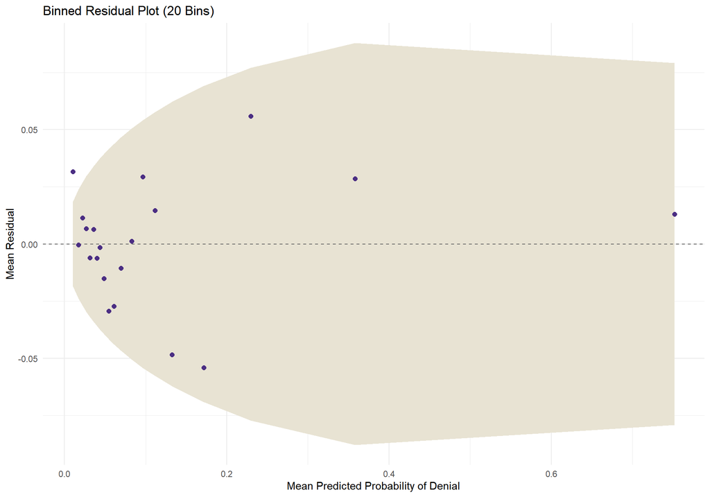

```r
binned <- hmda %>%
  mutate(p_hat = fitted(logit_full),   # predicted probability for each applicant
         resid = deny01 - p_hat,       # raw residual: observed (0/1) minus predicted
         bin = ntile(p_hat, 20)) %>%   # 20 groups of equal size by predicted probability
  group_by(bin) %>%
  summarise(p_mean = mean(p_hat),      # average prediction in the bin
            resid_mean = mean(resid),  # average residual in the bin
            se2 = 2 * sqrt(p_mean * (1 - p_mean) / n())) # +/- 2 standard errors

ggplot(binned, aes(x = p_mean, y = resid_mean)) +
  geom_ribbon(aes(ymin = -se2, ymax = se2), fill = "#e8e3d3") + # band where ~95% of points should fall
  geom_hline(yintercept = 0, linetype = "dashed", color = "gray40") +
  geom_point(color = "#4b2e83", size = 2) +
  labs(x = "Mean Predicted Probability of Denial", y = "Mean Residual",
       title = "Binned Residual Plot (20 Bins)") +
  theme_minimal()
```

**Interpretation**: if many points fall outside the band, or the points form a clear pattern, the model is missing something (a nonlinear term, an interaction or an omitted variable). Like before, a good looking plot does **not** prove zero conditional mean.

### Adjustment to the Logistic Regression

Based on the checks, we make three changes:

1. **Remove the five applications with `pirat` $>1$**. Payments larger than income are not realistic for a mortgage applicant.
2. **Add a squared term for `pirat`** using `I()`, so the effect of debt can grow faster at high ratios.
3. **Group `lvrat` into categories**: low ($<0.8$), medium ($0.8$ to $0.95$) and high ($0.95$ or above). Lenders often use these cutoffs because a loan above 80% of the home value usually needs mortgage insurance.

```r
hmda_clean <- hmda %>%
  filter(pirat <= 1) %>%              # drop the 5 applications with payments above income
  mutate(lvrat_cat = cut(lvrat,       # turn loan to value into three groups
                         breaks = c(-Inf, 0.8, 0.95, Inf),
                         labels = c("low", "medium", "high"),
                         right = FALSE)) # intervals like [0.8, 0.95): 0.8 goes to "medium"

# check how many applications (and denials) fall in each group
table(hmda_clean$lvrat_cat, hmda_clean$deny)
```

```
##
##            no  yes
##   low    1305  104
##   medium  742  145
##   high     47   32
```

To compare models fairly with AIC or BIC, they **must use the same data**. So we refit the original model on `hmda_clean` first.

```r
# update() refits an existing model; here only the data change
logit_clean <- update(logit_full, data = hmda_clean)

# adjusted model: squared pirat term + loan to value groups
# I() tells R to compute pirat^2 as a number before using it in the formula
logit_adj <- glm(deny ~ pirat + I(pirat^2) + hirat + lvrat_cat + chist +
                   mhist + phist + selfemp + insurance + afam,
                 data = hmda_clean, family = binomial)
summary(logit_adj)
```

```
##
## Call:
## glm(formula = deny ~ pirat + I(pirat^2) + hirat + lvrat_cat +
##     chist + mhist + phist + selfemp + insurance + afam, family = binomial,
##     data = hmda_clean)
##
## Coefficients:
##                 Estimate Std. Error z value Pr(>|z|)
## (Intercept)      -3.7232     0.6823  -5.457 4.85e-08 ***
## pirat            -4.1490     3.4835  -1.191 0.233637
## I(pirat^2)       12.0879     4.2340   2.855 0.004305 **
## hirat            -0.6101     1.2803  -0.477 0.633712
## lvrat_catmedium   0.4893     0.1639   2.985 0.002839 **
## lvrat_cathigh     1.5795     0.3105   5.087 3.64e-07 ***
## chist2            0.7661     0.2141   3.578 0.000346 ***
## chist3            0.9182     0.3180   2.888 0.003883 **
## chist4            1.5786     0.3318   4.758 1.96e-06 ***
## chist5            1.1932     0.2495   4.783 1.73e-06 ***
## chist6            1.5482     0.2352   6.582 4.64e-11 ***
## mhist2            0.3993     0.1956   2.042 0.041172 *
## mhist3            0.5194     0.4755   1.092 0.274719
## mhist4            0.2354     0.6553   0.359 0.719365
## phistyes          1.2747     0.2105   6.056 1.40e-09 ***
## selfempyes        0.6444     0.2160   2.983 0.002856 **
## insuranceyes      4.5786     0.5608   8.165 3.21e-16 ***
## afamyes           0.6453     0.1806   3.574 0.000352 ***
## ---
## Signif. codes:  0 '***' 0.001 '**' 0.01 '*' 0.05 '.' 0.1 ' ' 1
##
## (Dispersion parameter for binomial family taken to be 1)
##
##     Null deviance: 1726.9  on 2374  degrees of freedom
## Residual deviance: 1247.4  on 2357  degrees of freedom
## AIC: 1283.4
##
## Number of Fisher Scoring iterations: 6
```

With a squared term, we cannot read `pirat` alone. The linear term is negative but not significant, and the squared term is positive and significant. Together they say: denial odds change little at low debt ratios and rise quickly at high ones. This matches the empirical logit plot.

### Compare Logistic Models

#### Likelihood Ratio Test

For nested models (one model is the other plus extra terms), the **likelihood ratio test** checks whether the extra terms improve the fit. It compares the deviances. Here we test whether the squared term is needed.

```r
# the same model without the squared term (". ~ . -" means keep everything, minus this)
logit_no_sq <- update(logit_adj, . ~ . - I(pirat^2))

# likelihood ratio test: does the bigger model fit significantly better?
anova(logit_no_sq, logit_adj, test = "Chisq")
```

```
## Analysis of Deviance Table
##
## Model 1: deny ~ pirat + hirat + lvrat_cat + chist + mhist + phist + selfemp +
##     insurance + afam
## Model 2: deny ~ pirat + I(pirat^2) + hirat + lvrat_cat + chist + mhist +
##     phist + selfemp + insurance + afam
##   Resid. Df Resid. Dev Df Deviance Pr(>Chi)
## 1      2358     1255.8
## 2      2357     1247.4  1   8.3815 0.003791 **
## ---
## Signif. codes:  0 '***' 0.001 '**' 0.01 '*' 0.05 '.' 0.1 ' ' 1
```

The p value is about 0.004, so the squared term significantly improves the model.

#### Model Summary Table

`modelsummary` works with `glm()` too. Use `exponentiate = TRUE` to show odds ratios instead of log odds.

```r
modelsummary(
  list(
    "Simple" = logit_simple,
    "Full (cleaned data)" = logit_clean,
    "Adjusted" = logit_adj
  ),
  exponentiate = TRUE, # show odds ratios instead of log odds
  stars = TRUE,        # significance stars
  fmt = 3,             # 3 decimal places
  title = "Logistic Regression of Mortgage Denial (Odds Ratios)",
  output = "html")
```

Logistic Regression of Mortgage Denial (Odds Ratios)

|  | Simple | Full (cleaned data) | Adjusted |
| --- | --- | --- | --- |
| (Intercept) | 0.016*** | 0.001*** | 0.024*** |
|  | (0.004) | (0.001) | (0.016) |
| pirat | 214.941*** | 251.831*** | 0.016 |
|  | (156.545) | (286.136) | (0.055) |
| afamyes | 3.571*** | 1.978*** | 1.907*** |
|  | (0.522) | (0.350) | (0.344) |
| hirat |  | 0.479 | 0.543 |
|  |  | (0.606) | (0.696) |
| lvrat |  | 5.873*** |  |
|  |  | (2.977) |  |
| chist2 |  | 2.015*** | 2.151*** |
|  |  | (0.426) | (0.461) |
| chist3 |  | 2.381** | 2.505** |
|  |  | (0.741) | (0.796) |
| chist4 |  | 4.897*** | 4.848*** |
|  |  | (1.618) | (1.609) |
| chist5 |  | 3.313*** | 3.298*** |
|  |  | (0.806) | (0.823) |
| chist6 |  | 4.426*** | 4.703*** |
|  |  | (1.022) | (1.106) |
| mhist2 |  | 1.509* | 1.491* |
|  |  | (0.292) | (0.292) |
| mhist3 |  | 1.684 | 1.681 |
|  |  | (0.791) | (0.799) |
| mhist4 |  | 1.769 | 1.265 |
|  |  | (1.110) | (0.829) |
| phistyes |  | 3.536*** | 3.578*** |
|  |  | (0.732) | (0.753) |
| selfempyes |  | 2.008** | 1.905** |
|  |  | (0.426) | (0.412) |
| insuranceyes |  | 96.108*** | 97.374*** |
|  |  | (53.461) | (54.603) |
| I(pirat^2) |  |  | 177702.854** |
|  |  |  | (752399.938) |
| lvrat_catmedium |  |  | 1.631** |
|  |  |  | (0.267) |
| lvrat_cathigh |  |  | 4.853*** |
|  |  |  | (1.507) |
| Num.Obs. | 2380 | 2375 | 2375 |
| AIC | 1597.4 | 1300.8 | 1283.4 |
| BIC | 1614.7 | 1393.1 | 1387.3 |
| Log.Lik. | -795.695 | -634.377 | -623.700 |
| F | 68.677 | 19.095 | 17.447 |
| RMSE | 0.31 | 0.27 | 0.27 |

+ p < 0.1, * p < 0.05, ** p < 0.01, *** p < 0.001

#### Performance Metrics

**AIC and BIC [smaller - better]**: same meaning as in the linear model.

**Pseudo R-squared [larger - better]**: there is no true R-squared for logistic regression. The most common substitute is **McFadden’s pseudo R-squared**, $1−logLmodellogLnull$. Values between 0.2 and 0.4 are usually seen as a good fit. Do not compare it directly with an OLS R-squared.

```r
# null model: intercept only, used as the baseline for pseudo R-squared
logit_null <- glm(deny ~ 1, data = hmda_clean, family = binomial)

# small helper function: McFadden pseudo R-squared = 1 - logLik(model) / logLik(null)
mcfadden <- function(model) {
  1 - as.numeric(logLik(model)) / as.numeric(logLik(logit_null))
}

# collect the fit measures of both models in one small table
data.frame(
  model = c("Full (cleaned data)", "Adjusted"),
  AIC = c(AIC(logit_clean), AIC(logit_adj)),
  BIC = c(BIC(logit_clean), BIC(logit_adj)),
  McFadden_R2 = c(mcfadden(logit_clean), mcfadden(logit_adj))
)
```

```
##                 model      AIC      BIC McFadden_R2
## 1 Full (cleaned data) 1300.755 1393.119   0.2652950
## 2            Adjusted 1283.400 1387.309   0.2776612
```

**In our case**: the adjusted model has lower AIC (1283 vs 1301), lower BIC (1387 vs 1393) and higher pseudo R-squared (0.278 vs 0.265). We will use it for prediction.

Look at `afamyes` across the three models in the table. The odds ratio drops from about 3.6 (simple) to about 1.9 (adjusted). Much of the raw gap is linked to differences in credit history and debt. But a significant gap remains after these controls. This is an *association* in observational data. It does not by itself prove discrimination, because other relevant factors may still be missing.

### Prediction with Logistic Regression

`predict()` for a `glm()` model has two scales, set by `type`:

- `type = "link"` (default): the predicted **log odds**.
- `type = "response"`: the predicted **probability** of $Y=1$.

```r
predict(logit_adj, type = "link")[1]     # first applicant: predicted log odds
```

```
##         1
## -2.102765
```

```r
predict(logit_adj, type = "response")[1] # first applicant: predicted probability
```

```
##         1
## 0.1088283
```

```r
# plogis() converts log odds back to probability: exp(x) / (1 + exp(x))
plogis(predict(logit_adj, type = "link")[1])
```

```
##         1
## 0.1088283
```

This is the same issue we had with the log price model. The default output (-2.10) is on the transformed scale. We need to transform it back, here with the logistic function instead of `exp()`. The first applicant has about an 11% predicted chance of denial.

#### From Probability to Classification

To turn probabilities into yes/no predictions, we pick a **threshold**. The default choice is 0.5.

```r
# predicted probability of denial for every applicant
hmda_clean$p_hat <- predict(logit_adj, type = "response")

# classify: "yes" if the probability is above 0.5
hmda_clean$pred_05 <- ifelse(hmda_clean$p_hat > 0.5, "yes", "no")

# confusion matrix: rows = what the model says, columns = what really happened
table(predicted = hmda_clean$pred_05, actual = hmda_clean$deny)
```

```
##          actual
## predicted   no  yes
##       no  2066  188
##       yes   28   93
```

The overall accuracy is $(2066+93)/2375≈91%$. That sounds good, but a model that predicts “no” for everyone would already be about 88% accurate, because only 12% of applications are denied. Our model only catches 93 of the 281 denials (33%).

When the outcome is rare, a lower threshold is often more useful. Try the overall denial rate as the threshold:

```r
# use the overall denial rate (about 0.12) as the threshold instead of 0.5
hmda_clean$pred_rate <- ifelse(hmda_clean$p_hat > mean(hmda_clean$deny01), "yes", "no")
table(predicted = hmda_clean$pred_rate, actual = hmda_clean$deny)
```

```
##          actual
## predicted   no  yes
##       no  1719   82
##       yes  375  199
```

Now we catch 199 of 281 denials (71%), but we also flag 375 approved applications by mistake. The right threshold depends on the cost of each type of error. We will look at this trade off (ROC curves, AUC) in Part B.

#### Average Marginal Effect: Back to Probabilities

Odds ratios are hard to explain to a general audience. An **average marginal effect (AME)** reports the change in **probability** instead. For a binary $X$ like `afam`, we predict every applicant twice, once with `afam = "yes"` and once with `afam = "no"`, keep everything else the same, and average the difference.

```r
# two copies of the data: everyone set to afam = "yes", and everyone set to "no"
# (all other columns stay exactly as observed)
data_yes <- hmda_clean %>% mutate(afam = factor("yes", levels = c("no", "yes")))
data_no  <- hmda_clean %>% mutate(afam = factor("no",  levels = c("no", "yes")))

# predict both versions for every applicant, take the difference, then average it
mean(predict(logit_adj, newdata = data_yes, type = "response") -
     predict(logit_adj, newdata = data_no,  type = "response"))
```

```
## [1] 0.05486026
```

Holding all other variables at their observed values, being an African American applicant is associated with about a **5.5 percentage point** higher probability of denial. Compare this with the odds ratio of about 1.9 for the same variable. Both are correct, but they answer different questions. (The `marginaleffects` package automates this for any model.)

### 📚 TODO: Explain the Results of Linear Regression

**6 points**

**You may discuss in small group, but you must prepare the submission by yourself. Generative AI is NOT allowed for write-up questions. This question does not require new coding — use the models you fit above (`simple_lm`, `log_simple_lm`, and the interaction models).**

These questions ask you to read and interpret your *own* Part A output.

1. [1 pt] In `simple_lm`, pick the coefficient on `sqft`. Write one sentence interpreting it in plain words, including its units (dollars per square foot) and whether it is statistically significant. How does its interpretation differ from the `sqft` coefficient in `log_simple_lm`?

   Hold year_built constant, every additional 1 sqft adds $501 value with p < 2e-16, means that is statistially significant. For the `log_simple_lm` one, the coefficient is the affct on log price, means that it shuold be interpreted as the exponentital function, which is the exponent of e. which roughly equallys 1.00036887, means that additional 1 sqft adds 0.037% of value.
2. [1 pt] Look back at the Residuals vs Fitted and Q–Q plots for `simple_lm`. Which two OLS assumptions showed problems, and what did the log transformation of `sale_price` do to them? Assumption 5: residuals vs. fitted diagram is funnel shape, means that the higher the fitted value, more scattered the residual value becomes. Assumption 6: the points on the right side of the Q-Q plot curve is sharply upward, means that the residual value is higher when standardized residuals are higher. It may indicate that some properties are significantly undervalued by the model. After log, the residual values are more evenly spread, largest standaridized residuals decreased from 20 to about 6, but there remains a slight S-shape, indicating that the problem is not fully solved.
3. [1 pt] We said a flat red line in Residuals vs Fitted does **not** prove zero conditional mean ($E[ε∣X]=0$). Name one variable that is almost certainly omitted from `simple_lm` and explain which direction it would bias the `sqft` coefficient. Location/View/Waterfront would be the omitted variable bias Better location has a positive effect on price, while houses in those location is oftenly larger, which also has a positive effect. The two positive effect makes the coefficient of sqft to be overestimated, as some premium of better location is wrongfully counted in size.
4. [1 pt] Compare the “Without Interaction” and “Interaction” models in the `modelsummary` table. Using Adjusted R-squared and AIC/BIC, which model would you choose and why? Does the significant interaction term change how you interpret the `sqft` effect? Interaction model’s Adj.R square is higher, both AIC and BIC are lower, therefore I would choose it.The significant interaction does change how we interpret sqft. Without the intercration varaiable, the model gives all properties a rigid slope for sqft, when with it, the slope is about 0.00023 + 0,00004*condition. While 0.00023 represents the slope when condition is 0, which is probably not possible. The positive interaction means that condition adds value to the property when other varaiables are held constant.
5. [1 pt] The VIF and Durbin–Watson results: report the values you got. Did either flag a concern? Given these are 2023 King County sales, why might the independence assumption still be violated even if Durbin–Watson looks acceptable? VIF: Both sqft and year_built are 1.096, far lower than 5, means that there is little multicollinerarity Durbin-Watson: 1.648, which is acceptable, means autocoorelation is okay. Even if DW is close to 2, the residuals may still show positive spatial autocorrealtion becasue nearby homes share neighbourhood characteristics.
6. [1 pt] In the Prediction section, the first raw prediction from the log model was about 13.57, far below any real sale price. Explain why that happened and what `exp()` fixes. Then interpret: for the interaction model, why can’t we read `exp(coef)` on the `sqft` main effect as “the price change per sqft” the same way we did for `log_simple_lm`?

   Because the model’s outcome is log(slae_price), predict function returns a log price, not actual money, exp function converts it back to dollars. In log_simple_lm, exp(β) is a constant multiplier. In the interaction model, the sqft effect is 0.00023 + 0.00004 * condition, so the multiplier exp (0.00023 + 0.0004 * condition) depends on condition, exp (0.00023) alone applies only when condition = 0, which is virtually impossible.

### 📚 TODO: Apply and Interpret Logistic Regression (HMDA)

**10 points**

**You may discuss in small group, but you must prepare the submission by yourself. Generative AI is allowed for the coding parts, but NOT for write-up answers. Your submission should be HTML or PDF knitted from this Rmd, with your code and output visible.**

Use the models you fit in the logistic regression section above (`logit_simple`, `logit_full`, `logit_adj`) and the `hmda_clean` data.

#### Reading the Model

1. [1 pt] Using `logit_adj`, report the odds ratio and its 95% confidence interval for `phistyes` (public bad credit record). Write one sentence interpreting it in plain words. Is it statistically significant? How can you tell from the confidence interval alone?

```r
round(exp(c(OR = unname(coef(logit_adj)["phistyes"]),
            confint(logit_adj, parm = "phistyes"))), 4)
```

```
##     OR  2.5 % 97.5 %
## 3.5776 2.3596 5.3900
```

```r
summary(logit_adj)
```

```
##
## Call:
## glm(formula = deny ~ pirat + I(pirat^2) + hirat + lvrat_cat +
##     chist + mhist + phist + selfemp + insurance + afam, family = binomial,
##     data = hmda_clean)
##
## Coefficients:
##                 Estimate Std. Error z value Pr(>|z|)
## (Intercept)      -3.7232     0.6823  -5.457 4.85e-08 ***
## pirat            -4.1490     3.4835  -1.191 0.233637
## I(pirat^2)       12.0879     4.2340   2.855 0.004305 **
## hirat            -0.6101     1.2803  -0.477 0.633712
## lvrat_catmedium   0.4893     0.1639   2.985 0.002839 **
## lvrat_cathigh     1.5795     0.3105   5.087 3.64e-07 ***
## chist2            0.7661     0.2141   3.578 0.000346 ***
## chist3            0.9182     0.3180   2.888 0.003883 **
## chist4            1.5786     0.3318   4.758 1.96e-06 ***
## chist5            1.1932     0.2495   4.783 1.73e-06 ***
## chist6            1.5482     0.2352   6.582 4.64e-11 ***
## mhist2            0.3993     0.1956   2.042 0.041172 *
## mhist3            0.5194     0.4755   1.092 0.274719
## mhist4            0.2354     0.6553   0.359 0.719365
## phistyes          1.2747     0.2105   6.056 1.40e-09 ***
## selfempyes        0.6444     0.2160   2.983 0.002856 **
## insuranceyes      4.5786     0.5608   8.165 3.21e-16 ***
## afamyes           0.6453     0.1806   3.574 0.000352 ***
## ---
## Signif. codes:  0 '***' 0.001 '**' 0.01 '*' 0.05 '.' 0.1 ' ' 1
##
## (Dispersion parameter for binomial family taken to be 1)
##
##     Null deviance: 1726.9  on 2374  degrees of freedom
## Residual deviance: 1247.4  on 2357  degrees of freedom
## AIC: 1283.4
##
## Number of Fisher Scoring iterations: 6
```

[output not shown]

2. [1 pt] `chist` is a factor with six levels. What is the reference category, and how do you know? Report the odds ratio for `chist6` and interpret it relative to the reference category.

```r
levels(hmda_clean$chist)
```

```
## [1] "1" "2" "3" "4" "5" "6"
```

```r
contrasts(hmda_clean$chist)
```

```
##   2 3 4 5 6
## 1 0 0 0 0 0
## 2 1 0 0 0 0
## 3 0 1 0 0 0
## 4 0 0 1 0 0
## 5 0 0 0 1 0
## 6 0 0 0 0 1
```

```r
exp(coef(logit_adj)["chist6"])
```

```
##   chist6
## 4.702994
```

Level 1 is the reference category. Its row in the contrast matrix contains only zeros, the the coefficient table has separate terms for levels 2 through 6. Ceteris paribus, applicants in category 6 have 4.7x denial odds than category 1 .

#### Building and Checking a New Model

3. [2 pts] Fit a new model called `logit_ext` that adds `single`, `hschool` and `unemp` to `logit_adj`. (Hint: `update(logit_adj, . ~ .
   - single + hschool + unemp)`.)
   - Run a likelihood ratio test comparing `logit_adj` and `logit_ext`. What are the null and alternative hypotheses? What do you conclude?
   - Report the AIC and BIC of both models. Do they agree? Explain why they might give different answers, and say which model you would keep.
   - Report the events per variable (EPV) for `logit_ext`. Is the sample still large enough?

```r
logit_ext <- update(logit_adj, . ~ . + single + hschool + unemp)
stopifnot(identical(rownames(model.frame(logit_adj)),
                    rownames(model.frame(logit_ext))))
anova(logit_adj, logit_ext, test = "LRT")
```

```
## Analysis of Deviance Table
##
## Model 1: deny ~ pirat + I(pirat^2) + hirat + lvrat_cat + chist + mhist +
##     phist + selfemp + insurance + afam
## Model 2: deny ~ pirat + I(pirat^2) + hirat + lvrat_cat + chist + mhist +
##     phist + selfemp + insurance + afam + single + hschool + unemp
##   Resid. Df Resid. Dev Df Deviance Pr(>Chi)
## 1      2357     1247.4
## 2      2354     1234.2  3   13.181 0.004262 **
## ---
## Signif. codes:  0 '***' 0.001 '**' 0.01 '*' 0.05 '.' 0.1 ' ' 1
```

```r
data.frame(model = c("Adjusted", "Extended"),
           AIC = AIC(logit_adj, logit_ext)$AIC,
           BIC = BIC(logit_adj, logit_ext)$BIC)
```

```
##      model      AIC      BIC
## 1 Adjusted 1283.400 1387.309
## 2 Extended 1276.219 1397.447
```

```r
events <- sum(model.response(model.frame(logit_ext)) == "yes")
slopes <- logit_ext$rank - 1
c(events = events, slopes = slopes, EPV = events / slopes)
```

```
## events slopes    EPV
## 281.00  20.00  14.05
```

[output not shown]

4. [1 pt] Run `vif()` on `logit_ext`. Square the last column and report the values for `pirat` and `I(pirat^2)`. Are these a real multicollinearity problem? (Hint: think about how `I(pirat^2)` is built from `pirat`.)

```r
v <- car::vif(logit_ext)
v[c("pirat", "I(pirat^2)"), ncol(v)]^2
```

```
##      pirat I(pirat^2)
##   16.62213   15.63215
```

```
VIF is 16.62 for pirat and 15.63 for pirat2. Their expected collinearity can inflate standard errors, but I would keep both terms to capture the nonlinear realtionship.
```

#### Prediction

5. [2 pts] Use `logit_adj` to predict the probability of denial for the hypothetical applicant below, once with `afam = "no"` and once with `afam = "yes"`.

   ```
   # helper: build a factor with the same levels as the column in hmda_clean
   # (predict() needs new data to use exactly the same factor levels)
   lv <- function(v, x) factor(x, levels = levels(hmda_clean[[v]]))

   # one row per scenario: same applicant, afam = "no" (row 1) and "yes" (row 2)
   applicant <- data.frame(
     pirat = 0.35, hirat = 0.28, lvrat_cat = lv("lvrat_cat", "medium"),
     chist = lv("chist", "2"), mhist = lv("mhist", "2"),
     phist = lv("phist", "no"), selfemp = lv("selfemp", "no"),
     insurance = lv("insurance", "no"), afam = lv("afam", c("no", "yes"))
   )
   ```

   - Report the two predicted probabilities and their difference in percentage points.
   - Compute the ratio of their **odds**, and compare it with `exp(coef(logit_adj)["afamyes"])`. Why are the two numbers the same, while the ratio of the two **probabilities** is not?

```r
lv <- function(v, x) factor(x, levels = levels(hmda_clean[[v]]))
applicant <- data.frame(
  pirat = 0.35, hirat = 0.28, lvrat_cat = lv("lvrat_cat", "medium"),
  chist = lv("chist", "2"), mhist = lv("mhist", "2"),
  phist = lv("phist", "no"), selfemp = lv("selfemp", "no"),
  insurance = lv("insurance", "no"), afam = lv("afam", c("no", "yes"))
)
p <- unname(predict(logit_adj, newdata = applicant, type = "response"))
odds <- p / (1 - p)
data.frame(afam = applicant$afam, probability = p, odds = odds)
```

```
##   afam probability      odds
## 1   no  0.09879652 0.1096273
## 2  yes  0.17287773 0.2090111
```

```r
c(difference_percentage_points = 100 * diff(p),
  odds_ratio = odds[2] / odds[1],
  exp_coefficient = unname(exp(coef(logit_adj)["afamyes"])),
  probability_ratio = p[2] / p[1])
```

```
## difference_percentage_points                   odds_ratio
##                     7.408121                     1.906560
##              exp_coefficient            probability_ratio
##                     1.906560                     1.749836
```

Changing afam from no to yes raises predicted denail probability from 9.88% to 17.29%. Since β_afam measures the change in log-odds, exponentiating gives the odds rator of 1.90656. Dividing the probability gives 1.749836.

6. [1 pt] Build a confusion matrix for `logit_adj` with a threshold of 0.3. Report (a) the share of actual denials the model catches and
   2. the share of actual approvals it wrongly flags. Compared with the 0.5 threshold in the lab, what did you gain and what did you lose?

```r
p_hat <- fitted(logit_adj)
for (threshold in c(0.3, 0.5)) {
  predicted <- factor(ifelse(p_hat > threshold, "yes", "no"),
                      levels = c("no", "yes"))
  cm <- table(predicted, actual = hmda_clean$deny)
  print(threshold)
  print(cm)
  print(c(denials_caught = cm["yes", "yes"] / sum(cm[, "yes"]),
          approvals_flagged = cm["yes", "no"] / sum(cm[, "no"])))
}
```

```
## [1] 0.3
##          actual
## predicted   no  yes
##       no  2010  147
##       yes   84  134
##    denials_caught approvals_flagged
##        0.47686833        0.04011461
## [1] 0.5
##          actual
## predicted   no  yes
##       no  2066  188
##       yes   28   93
##    denials_caught approvals_flagged
##        0.33096085        0.01337154
```

```
At 0.3, the model catches 134 of the 281 actual denials, and wrongfuly flags 84 of the 2,094 approvals. At 0.5, it is 93 and 28. Lowering the threshold identifies 41 additional denials in the cost of 56 extra false alarms.
```

#### Linking the Linear and Logistic Models

7. [1 pt] In both `log_simple_lm` and `logit_adj` we take `exp()` of a coefficient. Explain what `exp(coef)` means in each model (what is being multiplied?). Then explain why `predict()` returned 13.57 for the log price model and -2.10 for the logistic model, and which function brings each back to a meaningful scale.

```r
exp(predict(log_interaction_lm, newdata = sales[1, ]))
```

```
##        1
## 785876.9
```

```r
eta <- unname(predict(logit_adj, type = "link")[1])
c(log_odds = eta, odds = exp(eta), probability = plogis(eta))
```

```
##    log_odds        odds probability
##  -2.1027653   0.1221183   0.1088283
```

```
Holding other variables fixed, exp(β_sqft) multiplies fitted price /sqft. exp(β_afam) multiples denials odds when afam changes from no to yes. exp(13.57456) converts log price to $785.877 and plogis (-2.102765) converts log-odds to a 10.88* denical chance.
```

8. [1 pt] The odds ratio for `afamyes` drops from about 3.6 in `logit_simple` to about 1.9 in `logit_adj`. Using the omitted variable reasoning from the linear TODO (Question 3), explain why it dropped. Name one variable that is **not** in the HMDA data but could still bias the `afamyes` estimate, and say why we should call the result an *association* rather than proof of discrimination.

```r
logit_simple <- glm(deny ~ pirat + afam, data = HMDA, family = binomial())
# The middle column isolates the change in sample from the change in model.
simple_clean <- update(logit_simple, data = hmda_clean)
sapply(list(simple_original = logit_simple, simple_clean = simple_clean,
            adjusted_clean = logit_adj),
       function(model) unname(exp(coef(model)["afamyes"])))
```

```
## simple_original    simple_clean  adjusted_clean
##        3.570772        3.536932        1.906560
```

[output not shown]

### 📖 Optional: Logistic Regression in a Research Paper (Not Graded)

**Optional and not graded.** This reading shows how the logistic regression from the lab is used in published housing research. It is good practice for your final project and for reading papers in other courses.

**This section does not require any coding or submission.**

In this section, we will read a recent research paper published by Runstad Department faculty Rebecca J. Walter, Arthur Acolin, Ruoniu (Vince) Wang, Gregg Colburn, along with people from other institutions: [**Exploring the association between household compositional change and mobility of subsidized householders in the United States**](https://doi.org/10.1080/07352166.2024.2371380). You are able to find the PDF version within the lab folder.

This study examines the relationship between household compositional change (such as a partner, child, or adult entering or leaving the household) and residential mobility of subsidized householders in the US. They use the Annual Longitudinal Files 2005–2018 from U.S. Department of Housing and Urban Development, which is restricted-use data required researchers to apply to access. [Northwest Federal Statistical Research Data Center](https://csde.washington.edu/services/northwest-federal-statistical-research-data-center/) is the center within UW partnered with U.S. Census Bureau to provide such data access.

Please skim the paper first and use the following to guide your further reading, especially about the **Data and methods** and **Results** parts.

#### Settings

1. What is the unit of analysis of this study? What is the sample size $N$? Is this study cross-sectional or longitudinal (lecture 2 data)?
2. Why do you think U.S. Census Bureau requires us apply for the data usage instead of providing public access like American Community Survey (ACS) data?
3. In a research paper, we tend to include two parts of explanatory variables: (1) the **key explanatory variables (or variables of interest)**, which directly address the research question; and (2) the **control variables**, which account for other factors that might also influence the response variable. In this paper, what are the key explanatory variables and response variable?
4. What is the purpose of including local market characteristics as part of $X$? Even though we do not have access to the data, which variables could be multicollinear with local market characteristics?
5. Can we use normal linear regression for this study?
6. The follow picture shows model specification in page 8 of this paper. Do you find any problem with this equation and explanation, especially for the explanatory variable part?

[figure not shown]

Page 8 - Model Specification

#### Model Configurations and Results

This study uses logistic regression, which we practiced with the HMDA data in the lab section above. We replace $Y$ with $log(P/(1−P))$, where $P$ is the probability of $Y=1$. [This post from IBM is also helpful.](https://www.ibm.com/think/topics/logistic-regression) Think about this model:

$$log(P1−P)=β0+β1X1+β2X2$$

1. How should we interpret $β1$?
2. In the result tables of this paper, they use **Odds Ratio** rather than the coefficient of $X$. How could you calculate the coefficient $β$ for Household Member Enters or Exits (with odd ratio of 1.671)? The table below shows part of the results.
3. How much more likely are households with a compositional change (a member entering or exiting) to move, compared to those without, controlling for other factors?
4. What are the null and alternative hypotheses being tested by the t-value (398.7) for “Household Member Enters or Exits” in Model 1? What is the meaning of ‘***’?
5. They conducted at least three logistic regression models. Why did they do that?
6. The authors only use tables to present results. What is one way to visualize the adds ratio from this logistic model to show uncertainty of the results? You can use a plot example to illustrate.
7. The title of this paper uses *association* rather than *effect*, *impact*, or *influence*. Authors are also very cautious term usages in main text. What is the reason?

[figure not shown]

Table 5 - Logistic Regression Results

> **Looking ahead — Part B.** In Part B (released after the machine learning lecture) we will revisit regression from the *prediction* culture: we will deliberately set aside most of these assumptions and use `tidymodels` with lasso and ridge regression, cross-validation, and held-out test data to see which model predicts best on unseen sales.

## Acknowledgement

The materials are developed by Haoyu Yue based materials from [Dr. Feiyang Sun at UC San Diego](https://fsun.ucsd.edu/), Siman Ning and Christian Phillips at University of Washington, [Dr. Charles Lanfear at University of Cambridge](https://clanfear.github.io/).